# 2018201744-郭成城-第五周作业

## 1、对数据AQI设置分位数假设检验，给出空气质量指数的级别认定。

```r
AQI=read.csv('AQI.csv')#读取数据

p=pbinom(sum(AQI>=101),length(AQI$AQI),0.25)#分位数检验p值
p
```

```
## [1] 0.04909333
```

## 2、给出一组饮料连续120天的价格数据，请按新教材中的S1和S3进行趋势存在性检验，给出检验结果，同时和lm线性趋势检验的结果进行比较。

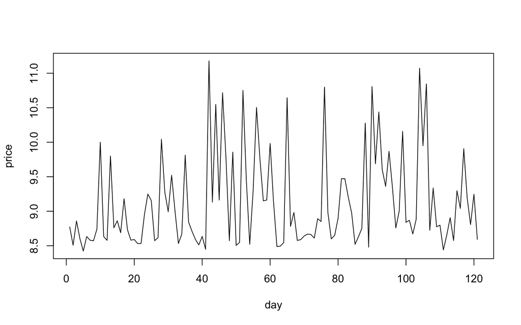

```r
data=read.csv('t2.txt')#读取数据
data=data$data
N=length(data)
plot(1:N,data,type='l',xlab='day',ylab='price')#从图像难以看到明显的趋势
```

### (1) Cox-Stuart S1统计量检验

$$H_0: 数据无趋势\quad v.s.\quad H_1: 数据有增长或减少趋势$$
构造$S_1$统计量与检验统计量$S^*$:
$$S_1=\sum_{i=1}^{\lfloor N/2 \rfloor}(N-2i+1)h_{i,N-i+1}$$
$$S_1^*=\frac{S_1-N^2/8}{\sqrt{N(N^2-1)/24}}=-1.935641$$
最终得到$p$值$P(S_1^*<-1.935641)=0.02639947<\alpha=0.05$，因此拒绝原假设，认为数据具有增长趋势。

```r
k=floor(N/2)#数对个数

#构造数对
pair1=seq(1,k)
pair2=seq(N,N-k+1,-1)
S1=sum((pair2-pair1)*((data[pair1]-data[pair2])>0))

#构造近似正态统计量
S1_star=(S1-N^2/8)/(sqrt(N*(N^2-1)/24))

#p-value
pnorm(S1_star)
```

```
## [1] 0.02639947
```

### (2) Cox-Stuart S3统计量检验

$$H_0: 数据无趋势\quad v.s.\quad H_1: 数据有增长或减少趋势$$

$$k=\lfloor\frac{N}{3}\rfloor$$
$$S_3=\sum_{i=1}^{k}h_{i,i+2k}$$
在大样本下，构造近似正态统计量，$Z=\frac{S_3-\frac{k}{2}}{\sqrt{k/4}}=-2.529822$，得到$p$值$p=2P(Z<-2.529822)=0.01141204<\alpha$，因此拒绝原假设，认为数据具有增长趋势。

```r
N=length(data)
k=floor(N/3)#数对个数

#构造数对
pair1=seq(1,k)
S3=sum((data[pair1]-data[pair1+2*k])>0)

#转换为符号检验
#为大样本，因此构建正态统计量
S3_star=(S3-k/2)/(sqrt(k/4))

#p-value
2*pnorm(S3_star)
```

```
## [1] 0.01141204
```

### (3) lm线性趋势检验

最后计算得到$p$值$p=0.0573979>\alpha$，因此在lm线性趋势检验下，不能认为数据具有趋势。

```r
#方法一：手动构建t检验统计量做检验
x=seq(1,N)#线性回归的自变量，即连续121天的编号

#将data与x进行线性回归，获得回归系数
fit=lm((data~(x)))

#构造t检验统计量
t=fit$coefficients[2]/sqrt(sum(fit$residuals^2)
    /((N-2)*sum((x-mean(x))^2)))

#计算t检验统计量的分位数，注意是双边检验，需要乘以2
2*(1-pt(t,N-2))
```

```
##          x
## 0.05739786
```

也可以使用R语言的*方差分析函数*（ANOVA，analysis of variance）直接得到$p$值（同样是双侧检验），$p$值与前述结果相同。

```r
#方法二：直接使用avona函数
anova(lm(data~(x)))$`Pr(>F)`#anova函数直接求得双侧p值
```

```
## [1] 0.05739786         NA
```

### （4）检验结果对比

在95%置信水平下：

|  | Cox-Stuart S1 | Cox-Stuart S3 | lm线性趋势检验 |
| --- | --- | --- | --- |
| $p$值 | 0.02639947 | 0.01141204 | 0.05739786 |
| 结论 | 增长趋势 | 增长趋势 | 无趋势 |

## 3、新教材P54，例2.5，南美洲失业率回归结果和书上的S1结果比较

```r
UNE.rate<-c(8.5,7.1,8.2,11.5,7.0,8.2,9.5,7.8,9.2,10.2,9.0,9.4,9.2,8.9,
            10.5,8.9,7.3,8.8,8.4,6.9,8.0,7.8,6.3,7.5,8.7,7.0,8.4,9.4,
            8.2,8.6,8.0,7.6,11.1,7.3,5.5,7.0)
N=length(UNE.rate)
x=1:N

#将UNE.rate与x进行线性回归
fit=lm((UNE.rate~(x)))
fit
```

```
##
## Call:
## lm(formula = (UNE.rate ~ (x)))
##
## Coefficients:
## (Intercept)            x
##     9.02238     -0.03589
```

建模得到截距项$\hat\beta_0=9.02238$，斜率$\hat\beta_1=-0.03589$，故数据的回归模型：
$$\hat y=9.02238-0.03589x$$
由于$\hat\beta_1<0$，因此确立假设：
$$H_0: 数据无趋势(\beta_1=0)\quad v.s.\quad H_1: 数据有减少趋势(\beta_1<0)$$
检验统计量：
$$t=\frac{\hat\beta_1}{\sqrt{\hat\sigma^2/\sum(x_i-\bar x)^2}}\sim t(n-2)$$
得到$p$值$p=0.04074966$，因此在95%的置信水平下拒绝原假设，认为数据具有减少趋势。对比教材p54页S1结果$p=0.01556232$，两种检验都得出了数据具有减小趋势的结果，但S1检验的结果更加显著。

```r
#t检验统计量，自由度N-2
t=fit$coefficients[2]/sqrt(sum(fit$residuals^2)
    /((N-2)*sum((x-mean(x))^2)))

#p-value（单侧）
pt(t,N-2)
```

```
##          x
## 0.04074966
```